# Visualization of Crime in San Francisco

Kent Mok

February 4, 2016

# Data Source

The data used in this analysis is from the crime dataset of Summer 2014 in San Francisco. It can be found here: https://github.com/uwescience/datasci_course_materials/blob/master/assignment6/sanfrancisco_incidents_summer_2014.csv Additional data for San Francisco can be found at: https://data.sfgov.org/

# Exploration of Data

A quick visualization of the data by summarizing the crime incidents by their category shows that the “Larceny/Theft” category outnumbers the rest of the categories by almost three times.

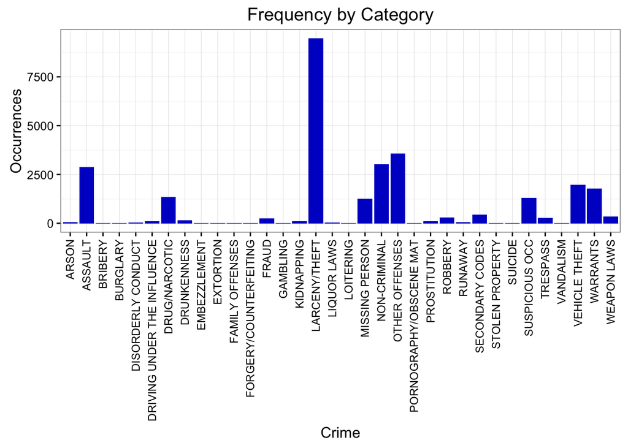

The top 10 occurrences of crimes by description are:

```
                    Description Frequency
   GRAND THEFT FROM LOCKED AUTO      3766
              STOLEN AUTOMOBILE      1350
                  LOST PROPERTY      1202
        PETTY THEFT OF PROPERTY      1125
                 WARRANT ARREST       980
   PETTY THEFT FROM LOCKED AUTO       955
                        BATTERY       903
                 FOUND PROPERTY       757
 GRAND THEFT FROM UNLOCKED AUTO       681
          SUSPICIOUS OCCURRENCE       677
```

# Data Analysis

A quick plot of the average occurrences of “Grand Theft From Locked Auto” by day reveals that there is a slight increase in occurrences on Fridays, Saturdays, and Sundays over the other weekdays.

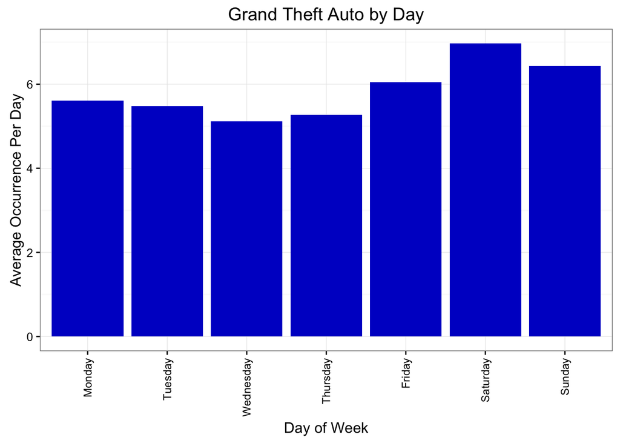

This could possibly be attributed to more people going out in the city and parking their vehicles in the city. If they leave any valuables in their vehicles, this would present more opportunities for break-ins and thefts.

A visualization of the crime occurrences by the hour of day shows a sharp increase during the hours of 6pm to 11pm.

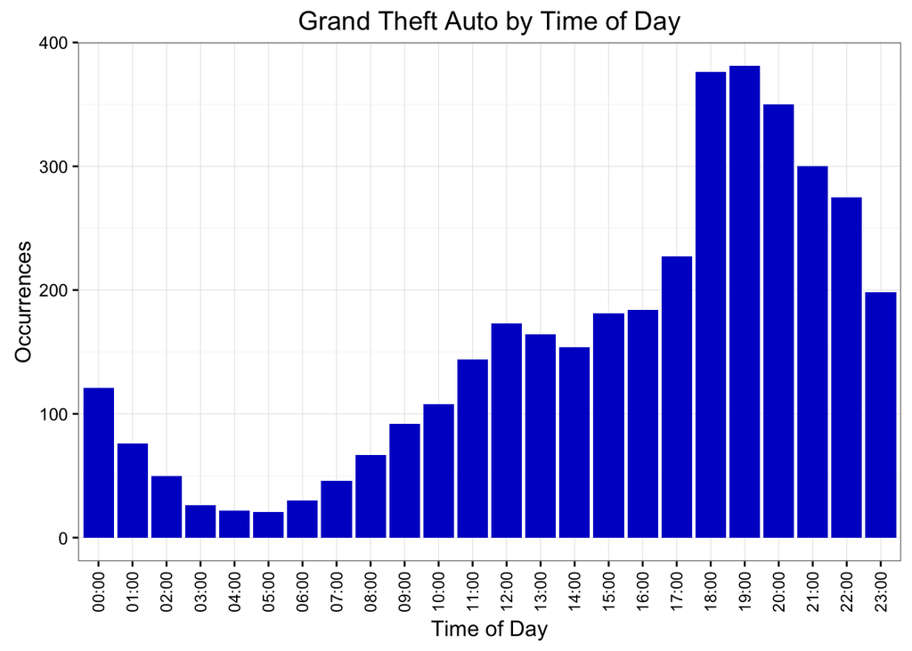

This could possibly be attributed by the aforementioned increase of vehicles with valuables parked in the city. Another contribution to the increase in grand theft from locked vehicles could be more suitable conditions for the activity due to sunset, which reduces available light and general visibility.

A plot of the locations of “Grand Theft From Locked Auto” incidents shows a high concentration of incidents near the Tenderloin, Fisherman’s Wharf, Embarcadero, SOMA, and Cathedral Hill areas.

[figure not shown]

These are all either tourist areas or areas with night life, which is in line with the reasoning that the occurrence of incidents are related to the opportunity from tourists visiting the city or others going to the city for a night out and leaving valuables in the vehicle.

# Conclusion

This analysis shows that the highest crime incidents are thefts from locked vehicles primarily in the hours between 6pm to 11pm. In order for the city to reduce this type of crime, it should inform tourists and visitors not to leave any valuables in their vehicles when they are parked in the Tenderloin, Fisherman’s Wharf, Embarcadero, SOMA, and Cathedral Hill areas. They would be well advised to be extra vigilant if they are parking and leaving their vehicles between the hours of 6pm to 11pm.

# Reproducibility

The code used in this analysis can be found at:  
https://github.com/kmok23/DataScienceComm